# Medical Insurance project

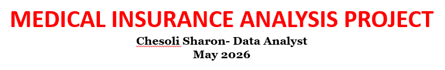

This project demonstrates how data science is used in healthcare to analyze medical insurance data and understand the factors that influence healthcare costs.The analysis focuses on identifying relationships between demographic characteristics, lifestyle habits, and insurance charges to generate meaningful insights for healthcare decision-making and predictive modeling.

**Project Objectives**

- Data Preparation: Clean and preprocess healthcare insurance data for analysis
- Pattern Exploration: Explore patterns and trends in medical insurance charges
- Demographic Analysis: Investigate how demographic factors such as age and gender influence healthcare expenses
- Lifestyle Impact: Examine the impact of lifestyle factors such as: Smoking habits, Body Mass Index (BMI)on insurance costs
- Family Variables: Analyze family-related variables such as the number of dependents covered by insurance
- Geographic Comparison: Compare insurance charges across different geographic regions

## **Data Collection and Loading**

```python
import pandas as pd
import numpy as np
import seaborn as sns
import matplotlib.pyplot as plt
```

```python
df = pd.read_csv("insurance_data.csv")
df.head()
```

|  | age | sex | bmi | children | smoker | region | charges |
| --- | --- | --- | --- | --- | --- | --- | --- |
| 0 | 19 | female | 27.900 | 0 | yes | southwest | 16884.92400 |
| 1 | 18 | male | 33.770 | 1 | no | southeast | 1725.55230 |
| 2 | 28 | male | 33.000 | 3 | no | southeast | 4449.46200 |
| 3 | 33 | male | 22.705 | 0 | no | northwest | 21984.47061 |
| 4 | 32 | male | 28.880 | 0 | no | northwest | 3866.85520 |

## **Data cleaning and Preprocessing**

```python
df["sex"]=pd.Categorical(df["sex"])
df["smoker"]=pd.Categorical(df["smoker"])
df["region"]=pd.Categorical(df["region"])
```

```python
df.info()
```

```
<class 'pandas.DataFrame'>
RangeIndex: 1338 entries, 0 to 1337
Data columns (total 7 columns):
 #   Column    Non-Null Count  Dtype
---  ------    --------------  -----
 0   age       1338 non-null   int64
 1   sex       1338 non-null   category
 2   bmi       1338 non-null   float64
 3   children  1338 non-null   int64
 4   smoker    1338 non-null   category
 5   region    1338 non-null   category
 6   charges   1338 non-null   float64
dtypes: category(3), float64(2), int64(2)
memory usage: 45.9 KB
```

```python
df = df.isnull().sum()
df
```

```
age         0
sex         0
bmi         0
children    0
smoker      0
region      0
charges     0
dtype: int64
```

```python
df.isnull()
```

```
age         False
sex         False
bmi         False
children    False
smoker      False
region      False
charges     False
dtype: bool
```

### Check for duplicates

```python
df.duplicated().sum()
```

```
np.int64(6)
```

```python
df = df.drop_duplicates()
```

```python
df.duplicated().sum()
```

```
np.int64(0)
```

### Check for Outliers

```python
df = pd.read_csv("insurance_data.csv")
df.head()
```

|  | age | sex | bmi | children | smoker | region | charges |
| --- | --- | --- | --- | --- | --- | --- | --- |
| 0 | 19 | female | 27.900 | 0 | yes | southwest | 16884.92400 |
| 1 | 18 | male | 33.770 | 1 | no | southeast | 1725.55230 |
| 2 | 28 | male | 33.000 | 3 | no | southeast | 4449.46200 |
| 3 | 33 | male | 22.705 | 0 | no | northwest | 21984.47061 |
| 4 | 32 | male | 28.880 | 0 | no | northwest | 3866.85520 |

```python
print(df)
```

```
      age     sex     bmi  children smoker     region      charges
0      19  female  27.900         0    yes  southwest  16884.92400
1      18    male  33.770         1     no  southeast   1725.55230
2      28    male  33.000         3     no  southeast   4449.46200
3      33    male  22.705         0     no  northwest  21984.47061
4      32    male  28.880         0     no  northwest   3866.85520
...   ...     ...     ...       ...    ...        ...          ...
1333   50    male  30.970         3     no  northwest  10600.54830
1334   18  female  31.920         0     no  northeast   2205.98080
1335   18  female  36.850         0     no  southeast   1629.83350
1336   21  female  25.800         0     no  southwest   2007.94500
1337   61  female  29.070         0    yes  northwest  29141.36030

[1338 rows x 7 columns]
```

```python
df["bmi"]
```

```
0       27.900
1       33.770
2       33.000
3       22.705
4       28.880
         ...
1333    30.970
1334    31.920
1335    36.850
1336    25.800
1337    29.070
Name: bmi, Length: 1338, dtype: float64
```

```python
type(df)
```

```
pandas.DataFrame
```

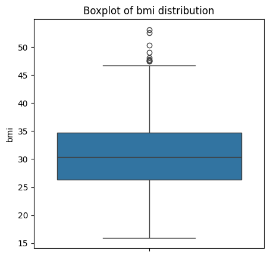

```python
import matplotlib.pyplot as plt
import seaborn as sns

plt.figure(figsize = (5, 5))
sns.boxplot(data = df, y = "bmi")
plt.title("Boxplot of bmi distribution")
plt.ylabel("bmi")
plt.show()
```

```python
Q1 = df["bmi"].quantile(0.25)
Q3 = df["bmi"].quantile(0.75)
IQR = Q3 - Q1

lower_bound = Q1 - 1.5 * IQR
upper_bound = Q3 + 1.5 * IQR
df1 = df[(df["bmi"] >= lower_bound) & (df["bmi"] <= upper_bound)]
print("outliers removed successfully")
```

```
outliers removed successfully
```

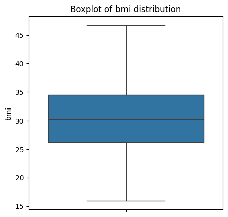

```python
plt.figure(figsize = (5, 5))
sns.boxplot(data = df1, y = "bmi")
plt.title("Boxplot of bmi distribution")
plt.ylabel("bmi")
plt.show()
```

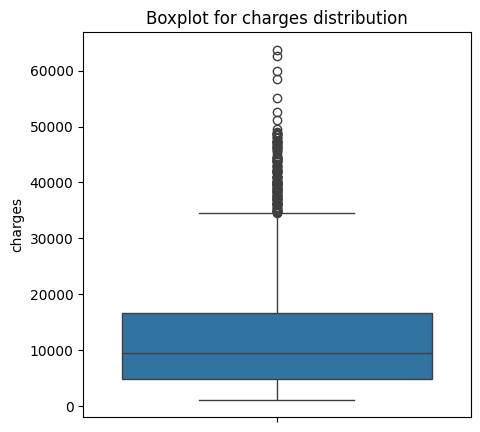

```python
plt.figure(figsize = (5, 5))
sns.boxplot(data = df, y = "charges")
plt.title("Boxplot for charges distribution")
plt.ylabel("charges")
plt.show()
```

```python
Q1 = df["charges"].quantile(0.25)
Q3 = df["charges"].quantile(0.75)
IQR = Q3 - Q1

lower_bound = Q1 - 1.5 * IQR
upper_bound = Q3 + 1.5 * IQR
df2 = df1[(df1["charges"] >= lower_bound) & (df1["charges"] <= upper_bound)]
print("outliers removed successfully")
```

```
outliers removed successfully
```

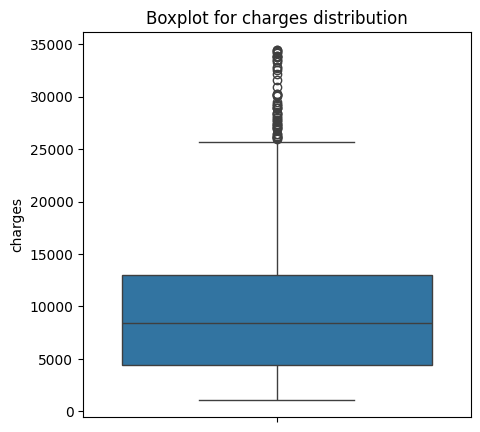

```python
plt.figure(figsize = (5, 5))
sns.boxplot(data = df2, y = "charges")
plt.title("Boxplot for charges distribution")
plt.ylabel("charges")
plt.show()
```

```python
Q1 = df2["charges"].quantile(0.25)
Q3 = df2["charges"].quantile(0.75)
IQR = Q3 - Q1

lower_bound = Q1 - 1.5 * IQR
upper_bound = Q3 + 1.5 * IQR
df3 = df2[(df2["charges"] >= lower_bound) & (df2["charges"] <= upper_bound)]
print("outliers removed successfully")
```

```
outliers removed successfully
```

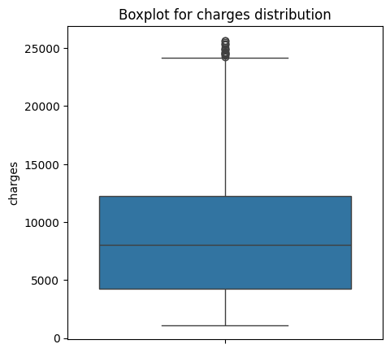

```python
plt.figure(figsize = (5, 5))
sns.boxplot(data = df3, y = "charges")
plt.title("Boxplot for charges distribution")
plt.ylabel("charges")
plt.show()
```

```python
Q1 = df3["charges"].quantile(0.25)
Q3 = df3["charges"].quantile(0.75)
IQR = Q3 - Q1

lower_bound = Q1 - 1.5 * IQR
upper_bound = Q3 + 1.5 * IQR
df4 = df3[(df3["charges"] >= lower_bound) & (df3["charges"] <= upper_bound)]
print("outliers removed successfully")
```

```
outliers removed successfully
```

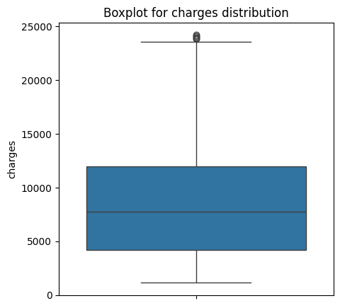

```python
plt.figure(figsize = (5, 5))
sns.boxplot(data = df4, y = "charges")
plt.title("Boxplot for charges distribution")
plt.ylabel("charges")
plt.show()
```

```python
Q1 = df4["charges"].quantile(0.25)
Q3 = df4["charges"].quantile(0.75)
IQR = Q3 - Q1

lower_bound = Q1 - 1.5 * IQR
upper_bound = Q3 + 1.5 * IQR
df5 = df4[(df4["charges"] >= lower_bound) & (df4["charges"] <= upper_bound)]
print("outliers removed successfully")
```

```
outliers removed successfully
```

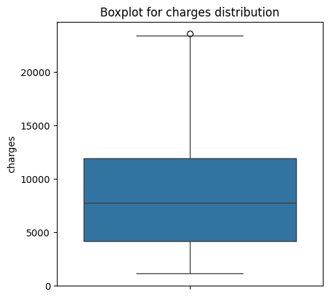

```python
plt.figure(figsize = (5, 5))
sns.boxplot(data = df5, y = "charges")
plt.title("Boxplot for charges distribution")
plt.ylabel("charges")
plt.show()
```

```python
Q1 = df5["charges"].quantile(0.25)
Q3 = df5["charges"].quantile(0.75)
IQR = Q3 - Q1

lower_bound = Q1 - 1.5 * IQR
upper_bound = Q3 + 1.5 * IQR
df6 = df5[(df5["charges"] >= lower_bound) & (df5["charges"] <= upper_bound)]
print("outliers removed successfully")
```

```
outliers removed successfully
```

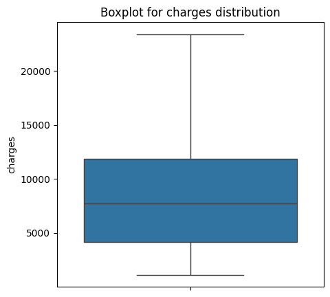

```python
plt.figure(figsize = (5, 5))
sns.boxplot(data = df6, y = "charges")
plt.title("Boxplot for charges distribution")
plt.ylabel("charges")
plt.show()
```

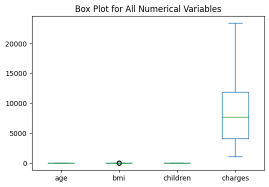

```python
df6.plot(kind='box', figsize=(6, 4))  # Plot with box plot style and set figure size to 4x3 inches
plt.title("Box Plot for All Numerical Variables")  # Add a title to the plot
plt.show()  # Display the plot
```

```python
Q1 = df6["bmi"].quantile(0.25)
Q3 = df6["bmi"].quantile(0.75)
IQR = Q3 - Q1

lower_bound = Q1 - 1.5 * IQR
upper_bound = Q3 + 1.5 * IQR
df7 = df6[(df6["bmi"] >= lower_bound) & (df6["bmi"] <= upper_bound)]
print("outliers removed successfully")
```

```
outliers removed successfully
```

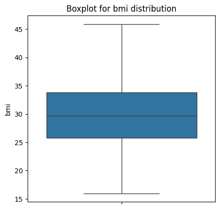

```python
plt.figure(figsize = (5, 5))
sns.boxplot(data = df7, y = "bmi")
plt.title("Boxplot for bmi distribution")
plt.ylabel("bmi")
plt.show()
```

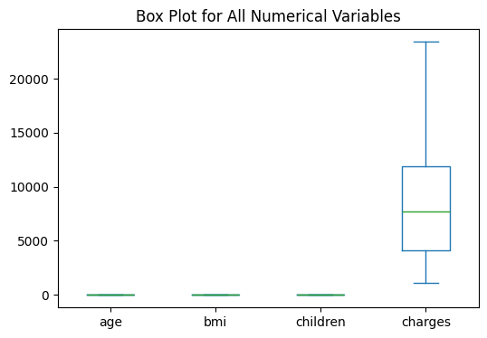

```python
df7.plot(kind='box', figsize=(6, 4))
plt.title("Box Plot for All Numerical Variables")
plt.show()
```

# **Data Visualization**

## Frequency of insurance charges

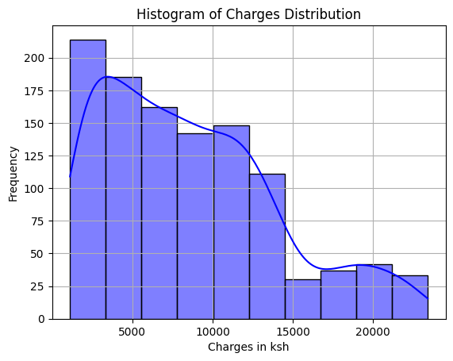

```python
import seaborn as sns

sns.histplot(df7, x="charges", bins=10, kde=True, color="blue")
plt.xlabel("Charges in ksh")
plt.ylabel("Frequency")
plt.title("Histogram of Charges Distribution")
plt.grid(True)
plt.show()
```

## Key Insights

The graph is "right-skewed" (or positively skewed). This means most of the data is bunched up on the left side (lower costs), while a long "tail" stretches out toward the higher costs on the right. The highest frequency is in the very first bin, meaning the most common charges are in the $1,000 to $5,000 range. As the cost increases, the frequency generally drops. There’s a significant "cliff" or drop-off after $15,000, where the number of occurrences becomes much smaller.

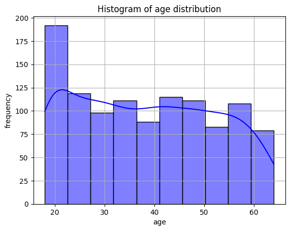

```python
import seaborn as sns

sns.histplot(df7, x="age", bins=10, kde=True, color="blue")
plt.xlabel("age")
plt.ylabel("frequency")
plt.title("Histogram of age distribution")
plt.grid(True)
plt.show()
```

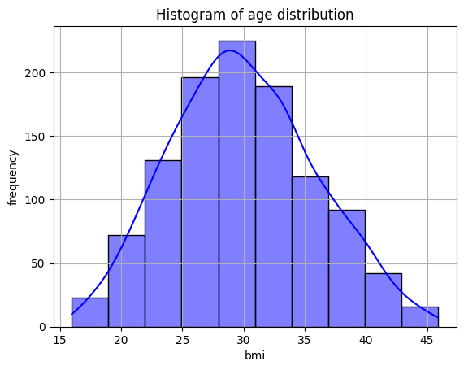

```python
import seaborn as sns

sns.histplot(df7, x="bmi", bins=10, kde=True, color="blue")
plt.xlabel("bmi")
plt.ylabel("frequency")
plt.title("Histogram of age distribution")
plt.grid(True)
plt.show()
```

## Key Insights

The histogram shows that the BMI (labeled as “bmi” on the x-axis, though the title mentions age distribution) follows an approximately bell-shaped, near-normal distribution centered around 28–31, where the highest frequency of observations occurs. Most individuals fall within the BMI range of about 24 to 35, indicating that the dataset is concentrated around moderate-to-high BMI values. The smooth blue density curve confirms this central clustering and suggests a fairly symmetric pattern, although there is a slight right skew, as values extend further toward 45 than toward the lower end near 16. Extremely low and extremely high BMI values are relatively rare, shown by the much smaller bars at both tails. Overall, the distribution indicates a population with predominantly overweight BMI levels, moderate variability, and no major outliers or multiple peaks, implying a single dominant group rather than separate subpopulations.

### Scatterplot for charges vs age by genders

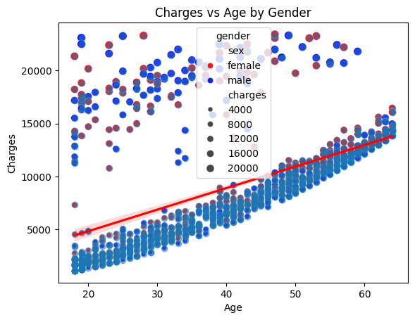

```python
plt.figure()
sns.scatterplot(df7, x="age", y="charges", hue="sex", size="charges", alpha=0.9, palette=['red', 'blue'])
sns.regplot(x='age', y='charges', data=df7, scatter_kws={'alpha':0.5}, line_kws={"color":"red"})
plt.title("Charges vs Age by Gender")
plt.xlabel('Age')
plt.ylabel('Charges')
plt.legend(title='gender')
plt.show()
```

## Key Insight:

The graph shows that medical charges generally increase with age, but the population is clearly divided into two distinct groups. Most people follow a predictable, lower-cost path that climbs steadily as they get older, while a smaller, separate group faces much higher charges regardless of their age. Because gender is evenly mixed in both groups, it isn't the cause of this price gap; the separation suggests that other significant factors—like lifestyle or health conditions—are what actually push certain individuals into that high-cost bracket.

## Scatter plot for charges vs age by smoker

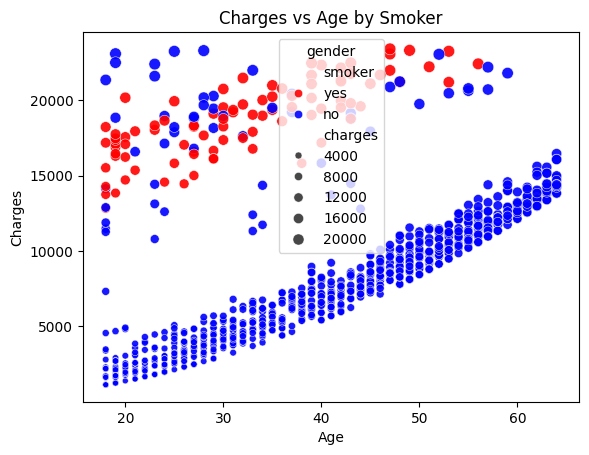

```python
plt.figure()
sns.scatterplot(df7, x="age", y="charges", hue="smoker", size="charges", alpha=0.9, palette=['red', 'blue'])
plt.title("Charges vs Age by Smoker")
plt.xlabel('Age')
plt.ylabel('Charges')
plt.legend(title='gender')
plt.show()
```

# Key Insight:

This graph confirms that smoking is a massive driver of costs, regardless of age. While both groups show charges increasing as people get older, smokers (top clusters) consistently pay thousands of dollars more than non-smokers (bottom clusters) at every age level. Essentially, smoking effectively "shifts" an individual into a much higher payment bracket, where even a young smoker might pay more than a non-smoker who is decades older.

## Scatterplot for charges vs bmi by smoker

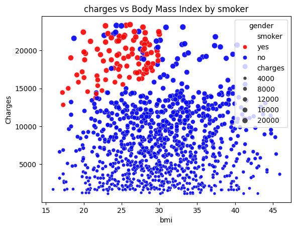

```python
import matplotlib.pyplot as plt
plt.figure()
sns.scatterplot(df7, x="bmi", y="charges", hue="smoker", size="charges", alpha=0.9, palette=['red', 'blue'])
plt.title("charges vs Body Mass Index by smoker")
plt.xlabel('bmi')
plt.ylabel('Charges')
plt.legend(title='gender')
plt.show()
```

## Key Insights

This graph shows that smoking status is the biggest factor in determining high costs, far outweighing BMI. While non-smokers (blue) stay in a lower price bracket regardless of their weight, smokers (red) are almost all pushed into the most expensive tier. Essentially, if you smoke, your charges are likely to be very high even with a lower BMI, whereas non-smokers generally maintain much lower costs even as their BMI increases.

## Boxplot

```python
df7.head()
```

|  | age | sex | bmi | children | smoker | region | charges |
| --- | --- | --- | --- | --- | --- | --- | --- |
| 0 | 19 | female | 27.900 | 0 | yes | southwest | 16884.92400 |
| 1 | 18 | male | 33.770 | 1 | no | southeast | 1725.55230 |
| 2 | 28 | male | 33.000 | 3 | no | southeast | 4449.46200 |
| 3 | 33 | male | 22.705 | 0 | no | northwest | 21984.47061 |
| 4 | 32 | male | 28.880 | 0 | no | northwest | 3866.85520 |

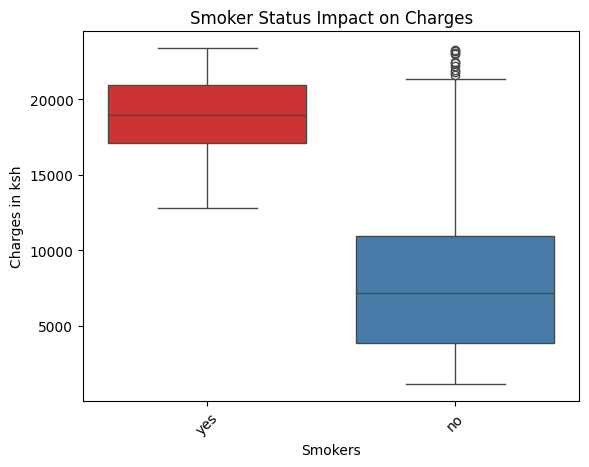

```python
sns.boxplot(x='smoker', y='charges', palette="Set1", data=df7)
plt.xlabel('Smokers')
plt.ylabel("Charges in ksh")
plt.title('Smoker Status Impact on Charges')
plt.xticks(rotation=45)
plt.show()
```

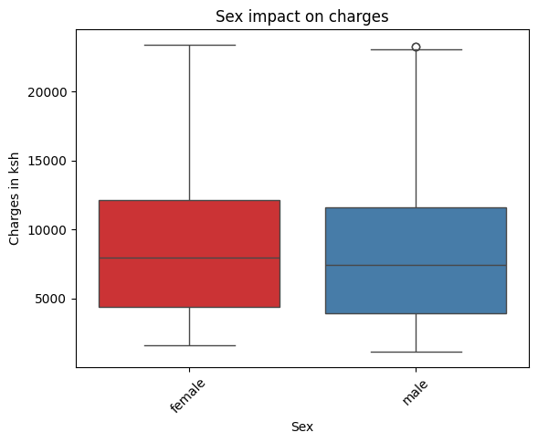

```python
sns.boxplot(x='sex', y='charges',palette="Set1", data=df7)
plt.xlabel('Sex')
plt.ylabel("Charges in ksh")
plt.title('Sex impact on charges')
plt.xticks(rotation=45)
plt.show()
```

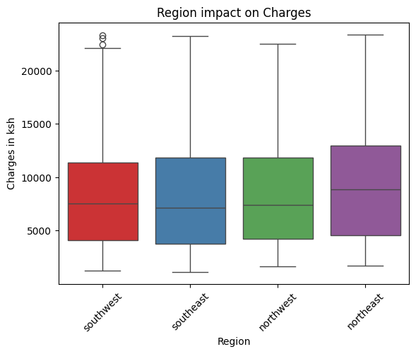

```python
import warnings
warnings.filterwarnings("ignore")

import seaborn as sns
sns.boxplot(x='region', y='charges',palette="Set1", data=df7)
plt.xlabel('Region')
plt.ylabel("Charges in ksh")
plt.title('Region impact on Charges')
plt.xticks(rotation=45)
plt.show()
```

## Key Insights:

The chart shows that while medical charges are relatively similar across most regions, the northeast tends to be the most expensive, with a higher average (median) cost than the others. The southwest, southeast, and northwest all share a similar baseline cost of around 7,500, but the southeast and northeast see much wider price swings, with some charges climbing significantly higher. Essentially, you're most likely to pay more in the northeast, though every region has at least some instances of high-cost cases.

## Count Plot

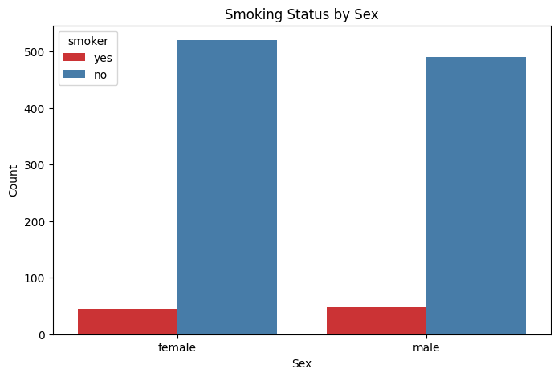

```python
plt.figure(figsize=(8,5))

sns.countplot(df7, x='sex',  hue='smoker', palette='Set1')

plt.title('Smoking Status by Sex')
plt.xlabel('Sex')
plt.ylabel('Count')

plt.show()
```

## Comment:

The chart shows that most people in both groups (male and female) are non-smokers. Female non-smokers are slightly more than male non-smokers, while the number of smokers is low and almost equal for both sexes. Overall, smoking is much less common compared to non-smoking in this dataset.

### Heatmap (Correlation Matrix)

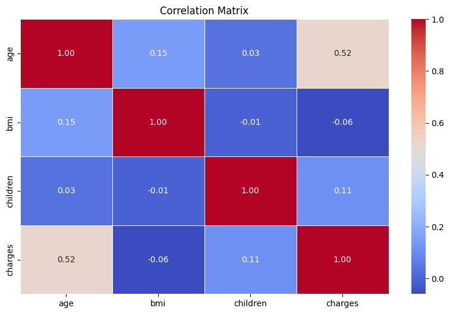

```python
corr_matrix = df7.select_dtypes(include=[np.number]).corr()

plt.figure(figsize=(10, 6))
sns.heatmap(corr_matrix, annot=True, cmap='coolwarm', fmt='.2f', linewidths=0.5)
plt.title('Correlation Matrix')
plt.show()
```

## Key Isights

The correlation heatmap shows the strength and direction of relationships among the variables age, BMI, children, and charges. Age has the strongest positive correlation with charges (0.52), indicating that charges tend to increase as age increases. Children also show a weak positive correlation with charges (0.11), meaning people with more children may have slightly higher charges. BMI has a very weak negative correlation with charges (-0.06), suggesting almost no linear relationship between BMI and charges in this dataset. The correlations among the independent variables themselves are also very low (age–BMI = 0.15, age–children = 0.03, BMI–children = -0.01), indicating that the variables are largely independent of each other and there is little risk of multicollinearity. Overall, the heatmap suggests that age is the variable most strongly associated with charges, while BMI and children have relatively weak relationships.

## **Hypothesis Testing**

```python
import pingouin as pg             # Necessary library
# Perform one-sample t-test against a population mean of 25000
age=df7['age']
test_value = 30
one_sample_test = pg.ttest(age, test_value)
one_sample_test
```

|  | T | dof | alternative | p_val | CI95 | cohen_d | power | BF10 |
| --- | --- | --- | --- | --- | --- | --- | --- | --- |
| T_test | 20.197791 | 1103 | two-sided | 1.939394e-77 | [37.62, 39.26] | 0.607882 | 1.0 | 5.438e+73 |

## Two sample t-test

```python
import pingouin as pg             # necessary library

# Separate age data by gender, dropping missing values
group_A = df7[df7['sex'] == 'male']['charges'].dropna()
group_B = df7[df7['sex'] == 'male']['charges'].dropna()

# Perform independent two-sample t-test (Welch's t-test)
two_sample_test = pg.ttest(group_A, group_B, paired=False)
two_sample_test
```

|  | T | dof | alternative | p_val | CI95 | cohen_d | power | BF10 |
| --- | --- | --- | --- | --- | --- | --- | --- | --- |
| T_test | 0.0 | 1076 | two-sided | 1.0 | [-668.63, 668.63] | 0.0 | 0.05 | 0.068 |

## Chi_Square Test

```python
import pandas as pd
from scipy import stats

contingency_table = pd.crosstab(df7["sex"], df7["smoker"])

# perform chi-square test
chi2, p, dof, expected = stats.chi2_contingency(contingency_table)

print("Chi-Square Test Result (sex vs smoker):")
print("Chi2:", chi2, "p-value:", p, "Degrees of Freedom:", dof)
print("p-value:", p)
print("Degrees of Freedom:", dof)

# Interpret the result
alpha = 0.05
if p < alpha:
    print("Reject the null hypothesis: there is a significant association between the variables.")
else:
    print("Fail to reject the null hypothesis: no significant association between the variables.")
```

```
Chi-Square Test Result (sex vs smoker):
Chi2: 0.20627615226825655 p-value: 0.6497019073792574 Degrees of Freedom: 1
p-value: 0.6497019073792574
Degrees of Freedom: 1
Fail to reject the null hypothesis: no significant association between the variables.
```

# Modeling

## Regresssion Analysis

```python
import statsmodels.api as sm
x=df7[["age","bmi","children"]]
y=df7["charges"]
# Fill missing values with column mean
x = x.fillna(x.mean())


x = sm.add_constant(x)

# Run regression
model = sm.OLS(y, x).fit()

print(model.summary())
```

```
                            OLS Regression Results
==============================================================================
Dep. Variable:                charges   R-squared:                       0.296
Model:                            OLS   Adj. R-squared:                  0.294
Method:                 Least Squares   F-statistic:                     154.3
Date:                Tue, 19 May 2026   Prob (F-statistic):           1.89e-83
Time:                        22:51:06   Log-Likelihood:                -10868.
No. Observations:                1104   AIC:                         2.174e+04
Df Residuals:                    1100   BIC:                         2.176e+04
Df Model:                           3
Covariance Type:            nonrobust
==============================================================================
                 coef    std err          t      P>|t|      [0.025      0.975]
------------------------------------------------------------------------------
const       3922.8467    780.985      5.023      0.000    2390.457    5455.236
age          209.7498     10.024     20.926      0.000     190.082     229.417
bmi         -127.9990     23.814     -5.375      0.000    -174.725     -81.273
children     416.5998    113.261      3.678      0.000     194.368     638.831
==============================================================================
Omnibus:                      418.629   Durbin-Watson:                   1.920
Prob(Omnibus):                  0.000   Jarque-Bera (JB):             1156.554
Skew:                           2.022   Prob(JB):                    7.20e-252
Kurtosis:                       5.965   Cond. No.                         286.
==============================================================================

Notes:
[1] Standard Errors assume that the covariance matrix of the errors is correctly specified.
```

## Key Insights

About 29.6% of the variation in charges is explained by age, BMI, and children, while 70% is affected by other factors that are not in this model

For every 1-year increase in age, charges increase by about 210 units, holding other variables constant.

Since the p-value is very small(less than 0.05), age is a significant predictor.

For every 1-unit increase in BMI, charges decrease by about 128 units.

This result is statistically significant.

Each additional child increases charges by about 417 units, holding other variables constant.People with more children tend to have higher charges.

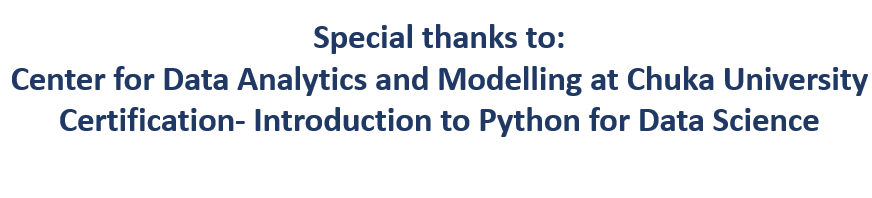